# AlphaSimR: Base population and traits

Marcio Resende[^1]

Marco Antonio Peixoto[^2]

Felipe Ferrao [^3]

Camila Azevedo [^4]

## Introduction

To start a set of simulations in the `AlphaSimR` package [@gaynor2021alphasimr], four steps must be implemented, as follows:

1. Simulate founder genomes/haplotypes.
2. Set global simulation parameters for a target trait/traits.
3. Model the breeding program.
4. Examine results by looking into population individuals’ metrics.

In this vignette, we will implement and further explore the first two.

## Founder genomes

First, we clean our working environment and download/load the AlphaSimR package.

```r
# install.packages('AlphaSimR')
require(AlphaSimR)
```

To create the founder genome we may use the function `runMacs()`. It uses the method from Chen et al. [@chen2009fast] to simulate a set of haplotypes and, from that, a species-specific demography. This allows us to simulate a base genome with characteristics of the target crop that we are working with.

```r
# Founder genome
founderGenomes = runMacs(nInd = 3, # Number of individuals that compose the base population
                         nChr = 3, # Number of chromosome pairs of the target species
                         segSites = 100, # number of segregation sites
                         species = "MAIZE", # We can use the base parameters and we have available in the package MAIZE, WHEAT, CATTLE, and GENERIC.
                         ploidy = 2) # Setting the ploidy


# Object created
founderGenomes
```

```
## An object of class "MapPop"
## Ploidy: 2
## Individuals: 3
## Chromosomes: 3
## Loci: 300
```

```r
# Genetic map of the segregation sites
founderGenomes@genMap
```

```
## $`1`
##        1_1        1_2        1_3        1_4        1_5        1_6        1_7
## 0.00000000 0.02837015 0.06204803 0.07339700 0.08044982 0.09837414 0.10184805
##        1_8        1_9       1_10       1_11       1_12       1_13       1_14
## 0.12349998 0.15468114 0.19101596 0.20782833 0.21936731 0.22275889 0.22957566
##       1_15       1_16       1_17       1_18       1_19       1_20       1_21
## 0.23631150 0.25513641 0.27870106 0.28101047 0.30915820 0.31636872 0.32954374
##       1_22       1_23       1_24       1_25       1_26       1_27       1_28
## 0.33057522 0.33329006 0.34610576 0.35355402 0.35432379 0.35702597 0.38477560
##       1_29       1_30       1_31       1_32       1_33       1_34       1_35
## 0.39187492 0.39911256 0.41190322 0.43425446 0.44349615 0.46026235 0.46422103
##       1_36       1_37       1_38       1_39       1_40       1_41       1_42
## 0.53139085 0.54782000 0.57319211 0.58041145 0.58442975 0.59284263 0.64447910
##       1_43       1_44       1_45       1_46       1_47       1_48       1_49
## 0.66688473 0.68060523 0.69439783 0.74476851 0.74992437 0.76175479 0.77944388
##       1_50       1_51       1_52       1_53       1_54       1_55       1_56
## 0.79800006 0.91755968 0.95245205 0.96469948 0.99690802 1.00777808 1.02441336
##       1_57       1_58       1_59       1_60       1_61       1_62       1_63
## 1.03972127 1.04557799 1.09261641 1.09315969 1.10024097 1.10548083 1.11927284
##       1_64       1_65       1_66       1_67       1_68       1_69       1_70
## 1.14982830 1.15116527 1.16576716 1.18061177 1.19477834 1.20070795 1.20393348
##       1_71       1_72       1_73       1_74       1_75       1_76       1_77
## 1.25704089 1.27694138 1.29249395 1.30358691 1.38402779 1.40367609 1.40385738
##       1_78       1_79       1_80       1_81       1_82       1_83       1_84
## 1.47606174 1.47957721 1.48938939 1.50696747 1.52910589 1.56570824 1.58070877
##       1_85       1_86       1_87       1_88       1_89       1_90       1_91
## 1.60433924 1.60601297 1.62578110 1.66366388 1.66511607 1.67581085 1.71791374
##       1_92       1_93       1_94       1_95       1_96       1_97       1_98
## 1.72920237 1.75958021 1.77857754 1.77932684 1.81260863 1.83200474 1.83425295
##       1_99      1_100
## 1.83949863 1.85807397
##
## $`2`
##        2_1        2_2        2_3        2_4        2_5        2_6        2_7
## 0.00000000 0.05797398 0.06037806 0.07078029 0.09530634 0.12347324 0.15513628
##        2_8        2_9       2_10       2_11       2_12       2_13       2_14
## 0.19105499 0.20365944 0.22904424 0.23717559 0.23932378 0.25155779 0.27501583
##       2_15       2_16       2_17       2_18       2_19       2_20       2_21
## 0.28060696 0.30838358 0.30999540 0.31143174 0.31958103 0.33153832 0.36296996
##       2_22       2_23       2_24       2_25       2_26       2_27       2_28
```

[output cut: 40 more lines]

```
## 0.93765031 0.96043110 0.98513528 1.00258854 1.06297322 1.06446905 1.09568045
##       3_57       3_58       3_59       3_60       3_61       3_62       3_63
## 1.10571552 1.12600325 1.13584161 1.18553192 1.19717885 1.21398181 1.23224654
##       3_64       3_65       3_66       3_67       3_68       3_69       3_70
## 1.24954551 1.27075360 1.27137476 1.28029865 1.28891809 1.29833942 1.31692184
##       3_71       3_72       3_73       3_74       3_75       3_76       3_77
## 1.32118922 1.33453885 1.35259349 1.35448529 1.36444254 1.36900948 1.37535088
##       3_78       3_79       3_80       3_81       3_82       3_83       3_84
## 1.39430859 1.39526848 1.48549425 1.54484832 1.60956903 1.62134005 1.62463881
##       3_85       3_86       3_87       3_88       3_89       3_90       3_91
## 1.63525162 1.70867116 1.71318687 1.73152479 1.74249122 1.76645422 1.79716402
##       3_92       3_93       3_94       3_95       3_96       3_97       3_98
## 1.80092107 1.83379637 1.86655244 1.89922636 1.92158622 1.92905837 1.93806440
##       3_99      3_100
## 1.95827053 1.96909361
```

When we choose the species in the argument *species*, four parameters are automatically adjusted:

```r
# Genome length (i.e. Maize)
genLen = 1.43

# Effective population size (Ne)
Ne = 50

# Demographic bottlenecks
speciesParams = "8E8 -t 4E-7 -r 3.6E-7"

# Species history
speciesHist = "-eN 0.03 1 -eN 0.05 2 -eN 0.10 4 -eN 0.15 6"
```

**Obs**: `runMacs()` functions offers four target species with their demography already implemented in the package. Other than that, we can use `runMacs2()` function to set our own species characteristics (further discussed).

## Traits

With the founder genomes in perspective, we can proceed to add the characteristics of the target trait or traits to the simulation. **AlphaSimR** has a vignette that we recommend you take a look at [link](https://cran.r-project.org/web/packages/AlphaSimR/vignettes/traits.pdf). It gives, thoroughly, an explanation on the traits of interest and how to interpret its effects.

### Single trait

#### **Additive trait**

We will start with a trait with only additive effects. For such, we have the following parameters:

```r
# Global simulation parameters from founder genomes.
SP = SimParam$new(founderGenomes)

# Additive trait
SP$addTraitA(nQtlPerChr = 15, # Number of QTL per chromosome
             mean = 10, # Trait mean
             var = 10) # Trait variance


# QTL effects (for the traits)
SP$traits[[1]]@addEff
```

```
##  [1]  5.18369706 -0.04665924  2.67819987  4.18069387 -4.13664613 -2.55717076
##  [7] -1.70496758  0.21118005 -0.15590280 -1.49761432 -0.69429385 -0.57762859
## [13]  0.37933696  0.48930026 -3.74719223 -0.99840873 -0.87839424  0.69904237
## [19]  0.64294367 -2.23251035  3.06182941 -0.81670421  1.89213880 -2.52716469
## [25]  0.87736165  0.48373715 -1.62513725 -2.89465910 -4.52812221  1.62640780
## [31]  2.91099670 -2.98542349  4.18165049 -0.48825013 -4.92205730 -0.30079222
## [37]  0.80483252  1.75289095  0.56586107 -3.46094774 -0.82691961 -3.72397542
## [43]  0.23932920  2.87351709 -0.56323985
```

After simulating the base genome and to set the trait characteristics, we can create individuals from that base genome for the trait of interest. We will use the function `newPop()`, as follows:

```r
# Creating individuals/population
basePop = newPop(founderGenomes)

# Gen param
genParam(basePop)
```

```
## $varA
##        Trait1
## Trait1     10
##
## $varD
##        Trait1
## Trait1      0
##
## $varAA
##        Trait1
## Trait1      0
##
## $varG
##        Trait1
## Trait1     10
##
## $genicVarA
##  Trait1
## 97.3069
##
## $genicVarD
## Trait1
##      0
##
## $genicVarAA
## Trait1
##      0
##
## $genicVarG
##  Trait1
## 97.3069
##
## $covA_HW
##    Trait1
## -39.21087
##
## $covD_HW
## Trait1
##      0
##
```

[output cut: 74 more lines]

```
## [1,] -16.905645
## [2,]  -9.256454
## [3,] -14.138122
##
## $gv_d
##      Trait1
## [1,]      0
## [2,]      0
## [3,]      0
##
## $gv_aa
##      Trait1
## [1,]      0
## [2,]      0
## [3,]      0
```

```r
# Looking at the population
# haplotypes
popHaplo = pullSegSiteHaplo(basePop)
popHaplo[, 1:10]
```

```
##     1_1 1_2 1_3 1_4 1_5 1_6 1_7 1_8 1_9 1_10
## 1_1   0   0   1   1   0   0   1   0   0    1
## 1_2   1   1   0   0   0   1   0   0   1    1
## 2_1   0   1   0   0   0   0   1   0   1    1
## 2_2   0   1   1   1   0   0   0   1   0    1
## 3_1   1   1   1   0   1   0   1   0   0    0
## 3_2   1   1   1   0   1   0   1   0   0    0
```

```r
# Check the genotypes
popGeno = pullSegSiteGeno(basePop)
popGeno[, 1:10]
```

```
##   1_1 1_2 1_3 1_4 1_5 1_6 1_7 1_8 1_9 1_10
## 1   1   1   1   1   0   1   1   0   1    2
## 2   0   2   1   1   0   0   1   1   1    2
## 3   2   2   2   0   2   0   2   0   0    0
```

#### Allele frequency

Allele frequency describes the proportion of mutations at a locus and can be estimated from the haplotypes (popHaplo object).

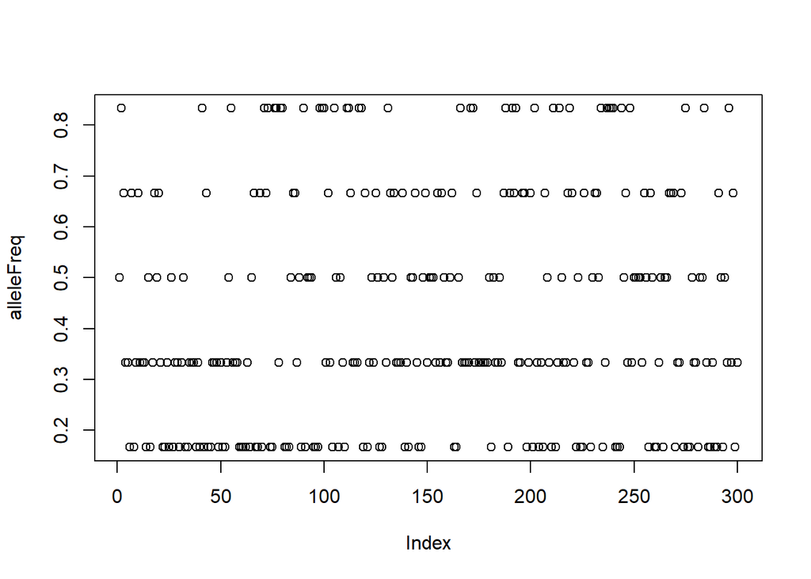

```r
# Allele frequency
alleleFreq = colMeans(popHaplo)

plot(alleleFreq)
```

#### **Trait with additive and dominance effects**

```r
# Global simulation parameters from founder genomes.
SP = SimParam$new(founderGenomes)

# Additive trait
SP$addTraitAD(nQtlPerChr = 15, # Number of QTLs controlling the trait per chromosome
              # nQtlPerChr = c(15, 5), # Alternative: QTL effect by chromosome
              mean = 10,
              var = 10,
              meanDD = 0.1, # dominance degree - it varies from 0-1 (meaning no-dominance and codominance)
              varDD = 0.2) # Variance for the degree of dominance

# QTL effects for additive effects
SP$traits[[1]]@addEff
```

```
##  [1] -0.46914754 -0.58306053 -0.34767036  0.92316884  0.99645004  0.75450683
##  [7]  0.32871618  1.22934896 -0.73158922  0.01915808  0.14479955 -0.80122761
## [13]  0.66372963 -0.38717444 -0.14783748 -0.07351241 -0.55890754 -0.31525680
## [19]  0.01173877  0.62706843 -0.21675538 -0.07157586 -0.29985650 -0.84245777
## [25]  0.11111941 -0.83235940 -0.59816762 -0.89828102 -1.10297484 -0.24262468
## [31] -0.22108602 -0.97637903 -0.13412185  1.09174369  0.60027153  0.41014302
## [37] -0.62615157 -0.34913145  0.25782116  0.04477153  0.10525056  0.64306248
## [43] -0.09944761 -0.14942588 -0.53277785
```

```r
# QTL effects for dominance effects
SP$traits[[1]]@domEff
```

```
##  [1]  0.2750242034  0.1904098522  0.0363930996  0.3931208598 -0.0388273378
##  [6]  1.1170181426  0.3178918892  0.7109197477 -0.0943834545  0.0228228573
## [11]  0.0329670550  0.1562114269  0.4028062570  0.1702880985  0.0390050082
## [16] -0.0118985179 -0.2700778732  0.0095246092 -0.0006421675  0.2888494366
## [21]  0.2740047238  0.0049068146  0.0730821887  0.5340481898 -0.0767003838
## [26]  0.4887583369  0.2491775900  0.5035265059  0.6604663907  0.0717346556
## [31]  0.0987234339 -0.1839668422 -0.1758822918  0.6928498148 -0.1926607890
## [36] -0.0192730709 -0.2381453295  0.1955765744  0.1997986418  0.0168470438
## [41]  0.0130297880  0.0410519645  0.0616899448  0.0346306881  0.0693281580
```

The implementation of traits in **AlphaSimR** follows a biological model, which is responsible for converting into a genetic value each individual genotype before created. In a straightforward way, the genetic value is used to create the individuals’ phenotypes. The biological effects presented in **AlphaSimR** are:

**A**: additive effect  
**D**: dominance effect  
**G**: genotype by environment interaction effect  
**E**: epistasis effect

So, we can create traits with the combinations of those effects (assuming that all of them as, at least, additive) using the **ADGE** framework, as it follows:

```r
# Traits that can be created in AlphaSimR:
SP$addTraitA()
SP$addTraitAD()
SP$addTraitADG()
SP$addTraitADEG()
SP$addTraitAG()
SP$addTraitAE()
SP$addTraitAEG()
```

It is important to have in mind that for dominance effects (**D**) we set the mean of the dominance degree (0-1) and variance, whereas for genotype by environment effect (**G**) and epistasis effect (**E**) we have just to adjust the variance.

## Importing external Data

The **AlphaSimR** package allows you to import genomic data and requires a genetic map and phased genotypes.

First, we load the genetic map in the format ‘Marker name, Chromosome, Position (in Morgans)’.

In the example below, we have a diploid species with 20 individuals, 10 chromosomes, each with 10 markers, and these markers are equally spaced along 1 Morgan chromosome.

```r
# Clean the directory
rm(list=ls())

# Load the External Data Set and Change the Directory
load("External_Data.RDATA")

# Genetic map
head(genMap)
```

```
##   marker chromosome  position
## 1     M1          1 0.0000000
## 2     M2          1 0.1111111
## 3     M3          1 0.2222222
## 4     M4          1 0.3333333
## 5     M5          1 0.4444444
## 6     M6          1 0.5555556
```

```r
dim(genMap) # nrows: Number of markers
```

```
## [1] 100   3
```

If we have phased haplotypes, the file needs to be 40 rows (the number of individuals times the ploidy level), with each individual having 100 loci based on the map above.

```r
# Haplotype file
haplo[1:6,1:6]
```

```
##     M1 M2 M3 M4 M5 M6
## ID1  0  0  0  0  1  1
## ID1  1  0  0  0  1  0
## ID2  1  0  0  0  0  0
## ID2  0  0  1  0  1  0
## ID3  1  0  0  1  1  0
## ID3  0  0  0  1  0  1
```

```r
dim(haplo) # nrows: Number of individuals multiplied by ploidy level, and ncols: number of markers
```

```
## [1]  40 100
```

If we don’t have phased haplotypes, we can simulate the haplotype phases multiple times.

```r
# Loading a function for later
sim_haplo_phase <- function(M, ploidy) {
  haplo <- NULL
  for (i in 1:nrow(M)) {
    b <- NULL
    for (j in 1:ncol(M)) {
      a <- rep(0, ploidy)
      if (M[i, j] > 0) {
        ones_count <- min(M[i, j], ploidy)
        a[1:ones_count] <- 1
      }
      b <- cbind(b, a)
    }
    haplo <- rbind(haplo, b)
    colnames(haplo)=colnames(M)
  }
  return(haplo)
}
```

```r
# SNP matrix
snp[1:6,1:6]
```

```
##     M1 M2 M3 M4 M5 M6
## ID1  1  2  2  0  1  0
## ID2  0  0  2  1  2  1
## ID3  0  0  2  1  1  1
## ID4  0  2  0  2  2  1
## ID5  0  2  2  0  0  0
## ID6  1  1  2  2  2  2
```

```r
dim(snp) # nrows: Number of individuals and ncols: number of markers
```

```
## [1]  20 100
```

```r
# Haplotype file simulated
haplo=sim_haplo_phase(M=snp, ploidy=2)
haplo[1:6,1:6]
```

```
##      M1 M2 M3 M4 M5 M6
## [1,]  1  1  1  0  1  0
## [2,]  0  1  1  0  0  0
## [3,]  0  0  1  1  1  1
## [4,]  0  0  1  0  1  0
## [5,]  0  0  1  1  1  1
## [6,]  0  0  1  0  0  0
```

We can also import the pedigree file.

```r
# Pedigree file
head(ped)
```

```
##    id mother father
## 1 ID1      0      0
## 2 ID2      0      0
## 3 ID3      0      0
## 4 ID4      0      0
## 5 ID5      0      0
## 6 ID6      0      0
```

To create the founder genome using the imported data set, we can utilize the `importHaplo()` function.

```r
# Create the founder population
founderPop = importHaplo(haplo = haplo,
                         genMap = genMap,
                         ploidy = 2,
                         ped = ped)
founderPop
```

```
## An object of class "NamedMapPop"
## Ploidy: 2
## Individuals: 20
## Chromosomes: 10
## Loci: 100
```

```r
# Set simulation parameters
# Initialize parameters with founder haplotypes
SP = SimParam$new(founderPop)
```

We can also load our own QTL effects or simulated traits using our imported genomic data set.

```r
# Load our own QTL effects
qtlEffects = data.frame(marker = c("M1", "M11","M80"),
                        aditiveEffect = c(1, -1, 1),
                        domEffect = c(0.3, 0, -0.3))

# Import in SimParam
SP$importTrait(markerNames = qtlEffects$marker,
               addEff = qtlEffects$aditiveEffect,
               intercept = 10,
               domEff = qtlEffects$domEffect,
               name = "Trait1")

# Create a population from the founder haplotypes
pop = newPop(founderPop)

# The population now works like any other AlphaSimR population
gv(pop)[1:6]
```

```
## [1] 11.3  7.7  9.0  8.0  9.7 10.0
```

## Multi-trait framework

The `AlphaSimR` package allows to simulate a set of traits for the individuals. For such, two strategies may be used.

The first strategy is to set all traits at once (using `$addTrait`). In this option, a correlation matrix between each pair of traits, for each effect, should be added, as follows:

```r
rm(list=ls())
# Founder genome
founderGenomes = runMacs(nInd = 3,
                         nChr = 3,
                         segSites = 100,
                         species = "MAIZE",
                         ploidy = 2)

# From the base population
SP = SimParam$new(founderGenomes)

# Alternative one - Setting the correlation between traits (Additive trait)
SP$addTraitA(nQtlPerChr = 20,
             mean = c(0, 10),
             var = c(0.5, 2),
             corA = matrix(c(1.0, 0.5,
                             0.5, 1.0), nrow = 2))


# QTL effects for trait one
SP$traits[[1]]@addEff
```

```
##  [1] -0.142143152 -0.231747279  0.037280501  0.241323211  0.466170017
##  [6] -0.020947934  0.268800417  0.300331789  0.163119673  0.161948220
## [11]  0.257923558  0.011057770 -0.242525896 -0.159215346  0.054591340
## [16]  0.037885842 -0.112546003  0.018034556 -0.000680395  0.189771209
## [21]  0.108079096  0.044779875  0.065963816 -0.069411910 -0.296322102
## [26] -0.124295219 -0.366513904  0.002606585 -0.193133240  0.084206880
## [31] -0.096099394 -0.094692383 -0.138634209  0.122174338 -0.007992793
## [36] -0.370329347 -0.248400746  0.173065196 -0.238836860 -0.138694402
## [41] -0.299586730 -0.036479705  0.051676110 -0.096081125  0.101470661
## [46]  0.363502128 -0.114901511 -0.007898188  0.011371373  0.160810591
## [51]  0.087136476 -0.151183493 -0.093444473 -0.094554789  0.093334354
## [56]  0.140026998 -0.277369277  0.191129913 -0.167607060 -0.025963792
```

```r
# QTL effects for trait two
SP$traits[[2]]@addEff
```

```
##  [1]  0.125478623 -0.522972651  0.036473845  0.242986657  0.160553220
##  [6]  0.254058715  0.314471073  0.307339592 -0.150048147  0.087288005
## [11] -0.360261774  0.002255296 -0.020234138 -0.391117692 -0.042612852
## [16]  0.271774728 -0.500350601  0.036925966 -0.397583544  0.083003958
## [21]  0.076336240 -0.005403775  0.236231812 -0.275502645 -0.303444662
## [26] -0.128764629 -0.526733075  0.452079453 -0.224879176  0.082232063
## [31] -0.291375578 -0.097366871 -0.297301476 -0.153165045  0.030150468
## [36] -0.162587373 -0.406641232  0.448614681 -0.075480501 -0.307897940
## [41]  0.269612222 -0.055447322  0.191399015 -0.424830693  0.325728201
## [46]  0.614474948 -0.113245566 -0.510349787 -0.035595465  0.389646651
## [51]  0.083338905  0.262430661 -0.259451883  0.182699100 -0.049186529
## [56]  0.188103556  0.033536809  0.034519220 -0.086452663  0.016930605
```

A second strategy in a multi-trait framework is to add each trait individually. In this case, we do not need to add the information of correlation between them. Another positive aspect of this second strategy is the possibility of setting a different number of QTLs controlling each trait simulated.

```r
# From the base population
SP = SimParam$new(founderGenomes)

# Alternative two - One trait at a time

# Trait one
SP$addTraitA(nQtlPerChr = 20,
             mean = 0,
             var = 0.5)

# Trait two
SP$addTraitA(nQtlPerChr = 5,
             mean = 100,
             var = 20)

# QTL effects for trait one
SP$traits[[1]]@addEff
```

```
##  [1] -0.09046418  0.03286128  0.16555261 -0.58137197  0.05974085 -0.04632199
##  [7]  0.10228479  0.08651719  0.06673763  0.12032382 -0.28616091  0.19547042
## [13] -0.07984843 -0.07171504  0.18011597  0.05654407 -0.21759435  0.22145362
## [19]  0.26495762 -0.15079060  0.13034380  0.10017915 -0.21751602  0.12914976
## [25]  0.26336063 -0.21864124  0.05236706  0.04529591 -0.10844205 -0.22982458
## [31] -0.24885050  0.16626600  0.21074405  0.04989468  0.23603430  0.27246961
## [37]  0.10822436 -0.19887765 -0.12542202  0.18079796  0.37016491  0.19298600
## [43]  0.16562591  0.20234541  0.08042761 -0.04964470 -0.21009523 -0.05045650
## [49]  0.33827500  0.04505360 -0.20002637 -0.08103277 -0.47208077  0.09044588
## [55] -0.27936894 -0.11201628 -0.21627754  0.11481747  0.23038725 -0.23076059
```

```r
# QTL effects for trait two
SP$traits[[2]]@addEff
```

```
##  [1]  0.1560651 -1.7373050  1.0854878  1.4841674  0.6598960 -1.3669863
##  [7] -1.7481451 -1.8820693  1.4712278  1.1098782  0.6278460 -1.0113660
## [13] -1.7741940  1.5316312  2.3220156
```

## Split argument

In breeding programs, such as maize, heterosis is harnessed by exploiting the crosses between heterotic groups. Usually, two distinct groups are used (*i*.*e*., maize dent and flint germplasm pools). The genetic divergence of these two pools is explained by their historic geographical separation and adaptation to different environments. It has undergone changes in the population structure and history of the base population.

For simulations that involve population separation in terms of generations, the **AlphaSimR** package offers the split argument in the `runMacs()` function. It represents an optional historic population split in terms of generations ago.

Below, we will simulate three different base genomes. The first one will use the default value (NULL) for the split argument. The second and third genomes will be split 10 and 50 generations ago, respectively. We will examine the base genome genotypes and explore them through a principal component analysis (PCA).

```r
rm(list=ls())
#------------------- Founder genome with no split
founderGenomes = runMacs(nInd = 200,
                         nChr = 5,
                         segSites = 100,
                         species = "MAIZE",
                         ploidy = 2,
                         split = NULL)

# From the base population
SP = SimParam$new(founderGenomes)

# Creating individuals/population
basePop = newPop(founderGenomes)

# Check the genotypes
popGeno = pullSegSiteGeno(basePop)

# PCA
pca_noSplit = prcomp(popGeno)

#------------------- Founder genome with split equals to 10
founderGenomes = runMacs(nInd = 200,
                         nChr = 5,
                         segSites = 100,
                         species = "MAIZE",
                         ploidy = 2,
                         split = 10)

# From the base population
SP = SimParam$new(founderGenomes)

# Creating individuals/population
basePop = newPop(founderGenomes)

# Check the genotypes
popGeno_10 = pullSegSiteGeno(basePop)

# PCA
pca_Split10 = prcomp(popGeno_10)


#------------------- Founder genome with split equals to 50
founderGenomes = runMacs(nInd = 200,
                         nChr = 5,
                         segSites = 100,
                         species = "MAIZE",
                         ploidy = 2,
                         split = 50)

# From the base population
SP = SimParam$new(founderGenomes)

# Creating individuals/population
basePop = newPop(founderGenomes)

# Check the genotypes
popGeno_50 = pullSegSiteGeno(basePop)

# PCA
pca_Split50 = prcomp(popGeno_50)
```

Plotting the PCA from each base population created.

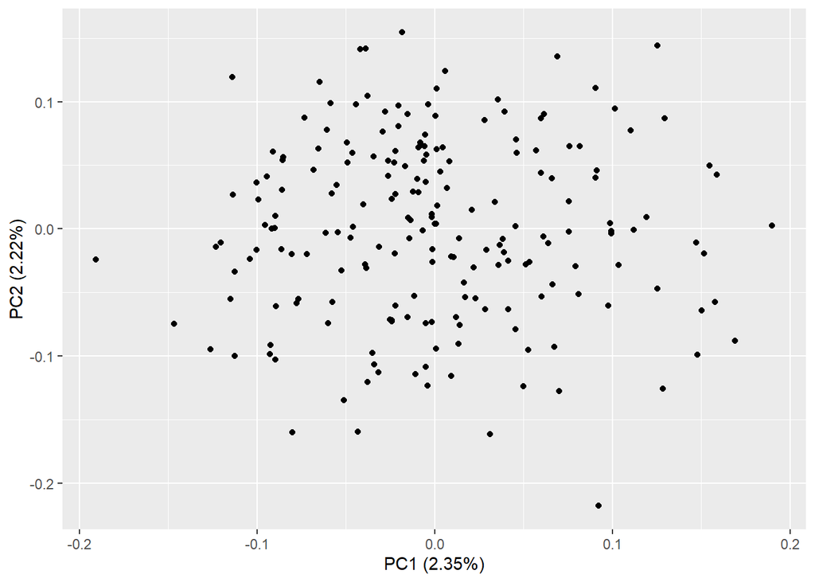

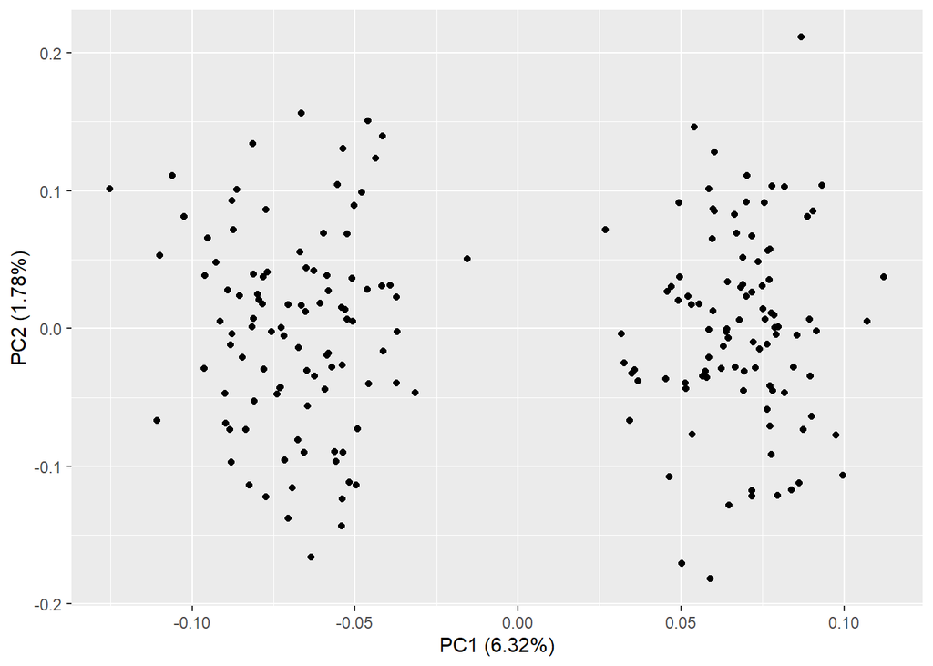

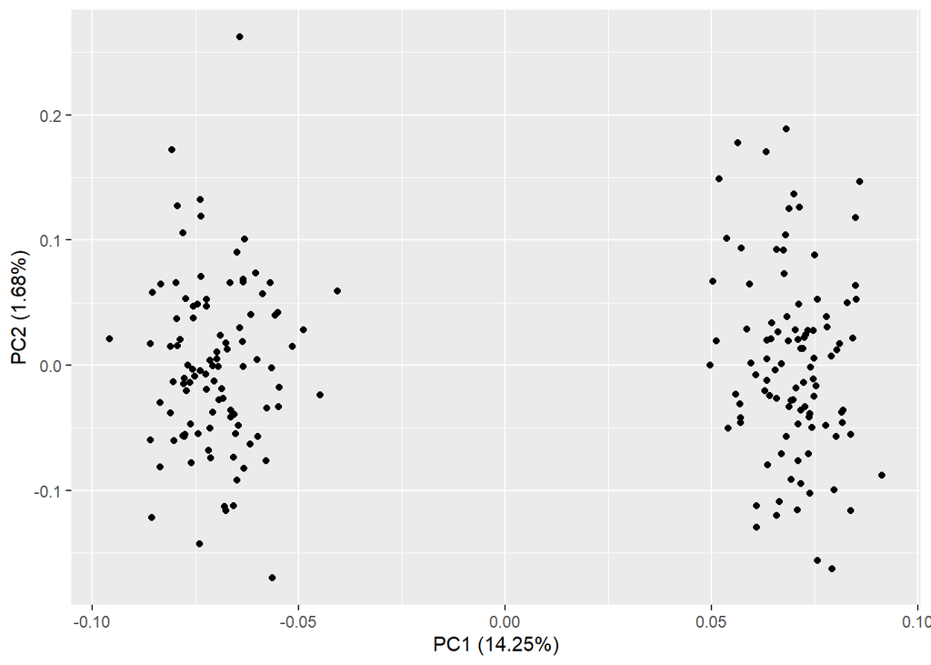

```r
# Plotting the PCA
library(ggfortify)
# Plot
par(mar = c(1, 3, .1, .1))
autoplot(pca_noSplit, data = popGeno)
autoplot(pca_Split10, data = popGeno_10)
autoplot(pca_Split50, data = popGeno_50)
```

## References

[^1]: Professor - University of Florida, mresende@ufl.edu
[^2]: Post doc - University of Florida, deamorimpeixotom@ufl.edu
[^3]: Professor - University of Florida, lferrao@ufl.edu
[^4]: Professor - Federal University of Viçosa, camila.azevedo@ufv.br